# Supplementary Materials for “Unreliability of Biomarker Research in Psychiatry”

Simon N. Vandekar, PhD, Panpan Zhang, PhD, Krishnan R. Patel, MD, Angela L. Jefferson, PhD, Frank Harrell, PhD

# 1 Selected Papers for Review

The papers reviewed (Table S1) were selected based on the original blog post, the section on MDD in the Abi-Dargham et al. (Abi-Dargham et al. 2023) review, and recent biomarker papers from 2025 and 2026 in psychiatry using EEG, imaging, or peripheral markers.

| Study | Source | Total sample size | Sample with biomarker | Sample per cell | Model type | Principles implicated |
| --- | --- | --- | --- | --- | --- | --- |
| (McGrath et al. 2013) | Original manuscript exemplar | 82 randomized; 65 protocol completers | 63 had pretreatment PET; 38 had usable PET and remission/nonresponse outcome | CBT NR 9, R 12; escitalopram NR 6, R 11 | Treatment selection biomarker using an interaction model | 1, 2, 3, 4, 5 |
| (Tozzi et al. 2020) | Abi-Dargham et al. (2023), Ref. 339 | 183: 124 MDD participants plus 59 healthy controls | 124 treated MDD participants completed baseline and follow-up fMRI, Go/No-Go task, and QIDS outcome | Escitalopram: NR 22, R 21; sertraline: NR 19, R 23; venlafaxine: NR 21, R 18. Smallest cell: 18 | Treatment-specific response association followed by post hoc classification | 1, 2, 4 |
| (Fischer et al. 2021) | Abi-Dargham et al. (2023), Ref. 340 | 184: 128 MDD participants plus 56 matched controls in the final longitudinal sample | 128 MDD participants had pre/post fMRI plus symptom and quality-of-life outcomes | Escitalopram NR 20, R 26; sertraline NR 17, R 25; venlafaxine NR 18, R 22 | Response-associated longitudinal biomarker analysis | 1, 2, 5 |
| (Nguyen et al. 2022) | Abi-Dargham et al. (2023), Ref. 345 | 222 EMBARC participants | 222 underwent baseline reward-task fMRI and supplied data for treatment-specific models | sertraline 106; placebo 116; bupropion 37 | Separate treatment-specific continuous-outcome prediction models. | 4 |
| (Barac et al. 2026) | Literature search | 296 randomized in EMBARC: placebo 150, sertraline 146 | 197 had clinical data; 118 had clinical, blood, EEG, and fMRI data used for the complete multimodal analysis | Sertraline 70; bupropion 24; placebo 24. | Treatment-specific remission prediction | 1, 2, 3, 5 |
| (Liu et al. 2025) | Literature search | 279 MDD participants in the final analysis | 279 had the required clinical and resting-state fMRI data after exclusions | Training 164: NR 90; R 74. Internal validation 66; external validation 49. | General prognostic remission prediction | 2 |

**eTable 1:** Papers reviewed in this report.

# 2 eMethods

## 2.1 VMAP Sample

Data were processed and analyzed using R version 4.6.1. Brain volumes were estimated using Multi-atlas Region Segmentation utilizing Ensembles (MUSE) (Doshi et al. 2016). Gray matter volumes were harmonized with legacy and expanded cohorts of VMAP using longitudinal comBat, including age, sex, race and ethnicity, diagnosis, *apolipoprotein E* (*APOE*) $\varepsilon4$ carrier status, Framingham Stroke Risk Profile (FSRP minus age points), and the interaction of diagnosis and follow-up time as non-imaging covariates (Beer 2020). For continuous MoCA, the outcome was modeled using a linear regression model with temporal lobe GMV, adjusting for age, sex, race and ethnicity, *APOE* $\varepsilon4$ carrier status, baseline MoCA, actual time interval, and total intracranial volume (ICV). For the dichotomized outcome, the same covariates were used in a logistic regression model. Parametric standard errors were used for both analyses.

To quantify uncertainty in biomarker ranking using bootstrapping, we resample from the dataset and repeat the full analyses employed in the study. Ranks for association strength were determined based on the normalized coefficient computed from linear regression models of ROI-specific GMV on MoCA, adjusting for the same set of covariates. In addition to obtaining 95% intervals for the range of ranks for each region, we computed confidence intervals for the normalized coefficient to identify regions whose intervals did not include zero.

```r
vmap_analysis_df <- readRDS("vmap_analysis_df.rds")

vmap_sample_table_df <- data.frame(
  age = vmap_analysis_df$age,
  raceethnicity.factor = vmap_analysis_df$raceethnicity.factor,
  apoe4pos.factor = vmap_analysis_df$apoe4pos.factor,
  np.moca = vmap_analysis_df$np.moca,
  intracranial_volume = vmap_analysis_df$muse.total.intracranial.vol.combat / 1000,
  temporal_lobe_volume = vmap_analysis_df$muse.temporal.lobe.vol.combat / 1000,
  np.moca.factor = vmap_analysis_df$np.moca.factor,
  visit_interval = vmap_analysis_df$muse.scan.date.diff.yr,
  check.names = FALSE
)

vmap_table_labels <- c(
  age = "Baseline Age (years)",
  raceethnicity.factor = "Race/Ethnicity",
  apoe4pos.factor = "APOE4",
  np.moca = "MoCA Total Score",
  intracranial_volume = "Intracranial Volume",
  temporal_lobe_volume = "Temporal Lobe Volume",
  np.moca.factor = "Dichotomized MoCA Score",
  visit_interval = "Visit interval (years)"
)
for (variable in names(vmap_table_labels)) {
  attr(vmap_sample_table_df[[variable]], "label") <- vmap_table_labels[[variable]]
}
attr(vmap_sample_table_df$intracranial_volume, "units") <- "cm<sup>3</sup>"
attr(vmap_sample_table_df$temporal_lobe_volume, "units") <- "cm<sup>3</sup>"

render_vmap_continuous <- function(x, ...) {
  c(
    "N" = sum(!is.na(x)),
    "Mean (SD)" = sprintf("%.1f +/- %.1f", mean(x, na.rm = TRUE), sd(x, na.rm = TRUE))
  )
}

table1::table1(
  ~ age + raceethnicity.factor + apoe4pos.factor + np.moca +
    intracranial_volume + temporal_lobe_volume + np.moca.factor + visit_interval,
  data = vmap_sample_table_df,
  render.continuous = render_vmap_continuous,
  render.missing = NULL
)
```

|  | Overall (N=559) |
| --- | --- |
| Baseline Age (years) | 559 |
| Mean (SD) | 68.3 +/- 8.9 |
| Race/Ethnicity |  |
| Non-Hispanic White | 464 (83.0%) |
| Other | 95 (17.0%) |
| APOE4 |  |
| No | 365 (65.3%) |
| Yes | 193 (34.5%) |
| MoCA Total Score | 543 |
| Mean (SD) | 25.6 +/- 3.5 |
| Intracranial Volume (cm<sup>3</sup>) | 489 |
| Mean (SD) | 1407.8 +/- 139.2 |
| Temporal Lobe Volume (cm<sup>3</sup>) | 402 |
| Mean (SD) | 196.8 +/- 21.4 |
| Dichotomized MoCA Score |  |
| Normal | 325 (58.1%) |
| Impaired | 218 (39.0%) |
| Visit interval (years) | 468 |
| Mean (SD) | 1.6 +/- 0.2 |

**eTable 2:** Sample characteristics for the VMAP data. Continuous variables show mean *±* the standard deviation. *N* is the number of non-missing values. Categorical variables show proportions with frequencies.

## 2.2 Secondary Analyses of McGrath et al. (2013)

Data from Figure 3 were analyzed by extracting data points from the sub-figures using the metaDigitize package in R. Effect sizes were calculated using the HDRS as the outcome variable. First, we used the data from Figure 3A to regress the outcome onto the treatment indicator and the insula PET glucose values and computed the effect size and test for the glucose by treatment interaction. To analyze the secondary outcome, we extracted the percent change in HDRS from Figure 3B and modeled the response status (percent change greater than 50%) by an interaction between treatment group and PET glucose values. Effect sizes with confidence intervals were computed for Cohen’s *f* using the RESI package with a parametric covariance estimator.

## 2.3 Sample Size Calculations for Dichotomization

The margin of error sample size for a dichotomized outcome computes the sample size needed for half a confidence interval width of 0.05. The standard error for a difference in proportions is

$$\sqrt{\frac{p_1(1-p_1)}{n} + \frac{p_2(1-p_2)}{n}},$$

where $n$ is the number in each group. The margin of error is largest when $p_1 \approx p_2 \approx 0.5$. For a 0.05 margin of error using a 95% confidence interval, we solve for $n$ based on half the width of the confidence interval

$$0.05^2 = z_{0.975}^2\frac{p_1(1-p_1)+p_2(1-p_2)}{n}
=1.96^2\times\frac{0.5}{n},$$

which gives $n\approx768$. The interaction parameter can be written as a difference-in-difference of proportions, so the variance of the difference-in-difference is the sum of four variances across independent groups. Thus, the variance of the interaction estimator increases by a factor of two requiring twice as many participants in each group.

```r
# Hide code chunks when knitting to PDF, keep them visible for HTML outputs.
if (identical(knitr::opts_knit$get("rmarkdown.pandoc.to"), "latex")) {
  knitr::opts_chunk$set(echo = FALSE)
}

packages <- as.character(expression(
  dplyr,
  formattable,
  Formula,
  ggplot2,
  Hmisc,
  rms,
  rVMAP
))

suppressMessages(rVMAP::load_pkg(packages))

# Sys.unsetenv("http_proxy")
# Sys.unsetenv("https_proxy")
# Sys.getenv(c("http_proxy", "https_proxy"))
# curl::curl_fetch_memory("https://cdn.posit.co/posit-ai/manifest.json")
```

```r
# vmap_dir <- file.path("C:",
#                       "Users",
#                       "zhanp15",
#                       "OneDrive - VUMC",
#                       "VMAC BIOSTAT",
#                       "DATA",
#                       "MAP",
#                       "mergedData")
#
# vmap_df <- readRDS(file.path(vmap_dir, "MAP_fm_f20260304_m20260304_combat20260304.rds"))
#
csf_var <- Hmisc::Cs(
  csf.fujirebio.ab42.2022,
  csf.lumipulse.ab42.2022.positive.factor,
  csf.lumipulse.ab42.40.2022.ratio,
  csf.lumipulse.ab42.40.2022.ratio.positive.factor,
  csf.fujirebio.ptau.2022,
  csf.lumipulse.ptau.2022.positive.factor,
  csf.fujirebio.tau.2022,
  csf.lumipulse.tau.2022.positive.factor
)

muse_var <- "muse.temporal.lobe.vol.combat"

muse_region_var <- c(
  'muse.cortical.csf.vol',
  # 1
  'muse.third.vent.vol',
  # 4
  'muse.fourth.vent.vol',
  # 11
  'muse.right.accumbens.area.vol',
  # 23
  'muse.left.accumbens.area.vol',
  # 30
  'muse.right.amygdala.vol',
  # 31
  'muse.left.amygdala.vol',
  # 32
  'muse.brain.stem.vol',
  # 35
  'muse.right.caudate.vol',
  # 36
  'muse.left.caudate.vol',
  # 37
  'muse.rh.cerebellum.ext.vol',
  # 38
  'muse.lh.cerebellum.ext.vol',
  # 39
  'muse.rh.cerebellum.wm.vol',
  # 40
  'muse.lh.cerebellum.wm.vol',
  # 41
  'muse.rh.hippocampus.vol',
  # 47
  'muse.lh.hippocampus.vol',
  # 48
  'muse.rh.inf.lat.vent.vol',
  # 49
  'muse.lh.inf.lat.vent.vol',
  # 50
  'muse.rh.lat.vent.vol',
  # 51
  'muse.lh.lat.vent.vol',
  # 52
  'muse.rh.pallidum.vol',
  # 55
  'muse.lh.pallidum.vol',
  # 56
  'muse.rh.putamen.vol',
  # 57
  'muse.lh.putamen.vol',
  # 58
  'muse.rh.thalamus.vol',
  # 59
  'muse.lh.thalamus.vol',
  # 60
  'muse.rh.ventraldc.vol',
  # 61
  'muse.lh.ventraldc.vol',
  # 62
  'muse.cerebellar.verm.lob1.5.vol',
  # 71
  'muse.cerebellar.verm.lob6.7.vol',
  # 72
  'muse.cerebellar.verm.lob8.10.vol',
  # 73
  'muse.lh.basal.forebrain.vol',
  # 75
  'muse.rh.basal.forebrain.vol',
  # 76
  'muse.right.frontal.lobe.wm.vol',
  # 81
  'muse.left.frontal.lobe.wm.vol',
  # 82
  'muse.right.occipital.lobe.wm.vol',
  # 83
  'muse.left.occipital.lobe.wm.vol',
  # 84
  'muse.right.parietal.lobe.wm.vol',
  # 85
  'muse.left.parietal.lobe.wm.vol',
  # 86
  'muse.right.temporal.lobe.wm.vol',
  # 87
  'muse.left.temporal.lobe.wm.vol',
  # 88
  'muse.right.fornix.vol',
  # 89
  'muse.left.fornix.vol',
  # 90
  'muse.right.posterior.limb.of.internal.capsule.inc.cerebral.peduncle.vol',
  # 91
  'muse.left.posterior.limb.of.internal.capsule.inc.cerebral.peduncle.vol',
  # 92
  'muse.right.anterior.limb.of.internal.capsule.vol',
  # 93
  'muse.left.anterior.limb.of.internal.capsule.vol',
  # 94
  'muse.corpus.callosum.vol',
  # 95
  'muse.rh.ant.g.cingulate.vol',
  # 100
  'muse.lh.ant.g.cingulate.vol',
  # 101
  'muse.rh.anterior.insula.vol',
  # 102
  'muse.lh.anterior.insula.vol',
  # 103
  'muse.rh.ant.g.orbital.vol',
  # 104
  'muse.lh.ant.g.orbital.vol',
  # 105
  'muse.rh.g.angular.vol',
  # 106
  'muse.lh.g.angular.vol',
  # 107
  'muse.rh.calcarine.ctx.vol',
  # 108
  'muse.lh.calcarine.ctx.vol',
  # 109
  'muse.rh.central.opperculum.vol',
  # 112
  'muse.lh.central.opperculum.vol',
  # 113
  'muse.rh.cuneus.vol',
  # 114
  'muse.lh.cuneus.vol',
  # 115
  'muse.rh.entorhinal.area.vol',
  # 116
  'muse.lh.entorhinal.area.vol',
  # 117
  'muse.rh.frontal.operculum.vol',
  # 118
  'muse.lh.frontal.operculum.vol',
  # 119
  'muse.rh.frontal.pole.vol',
  # 120
  'muse.lh.frontal.pole.vol',
  # 121
  'muse.rh.g.fusiform.vol',
  # 122
  'muse.lh.g.fusiform.vol',
  # 123
  'muse.rh.g.rectus.vol',
  # 124
  'muse.lh.g.rectus.vol',
  # 125
  'muse.rh.inf.g.occipital.vol',
  # 128
  'muse.lh.inf.g.occipital.vol',
  # 129
  'muse.rh.inf.g.temporal.vol',
  # 132
  'muse.lh.inf.g.temporal.vol',
  # 133
  'muse.rh.g.lingual.vol',
  # 134
  'muse.lh.g.lingual.vol',
  # 135
  'muse.rh.lat.g.orbital.vol',
  # 136
  'muse.lh.lat.g.orbital.vol',
  # 137
  'muse.rh.mid.g.cingulate.vol',
  # 138
  'muse.lh.mid.g.cingulate.vol',
  # 139
  'muse.rh.medial.frontal.ctx.vol',
  # 140
  'muse.lh.medial.frontal.ctx.vol',
  # 141
  'muse.rh.mid.g.frontal.vol',
  # 142
  'muse.lh.mid.g.frontal.vol',
  # 143
  'muse.rh.mid.g.occipital.vol',
  # 144
  'muse.lh.mid.g.occipital.vol',
  # 145
  'muse.rh.medial.g.orbital.vol',
  # 146
  'muse.lh.medial.g.orbital.vol',
  # 147
  'muse.rh.medial.g.postcentral.vol',
  # 148
  'muse.lh.medial.g.postcentral.vol',
  # 149
  'muse.rh.medial.g.precentral.vol',
  # 150
  'muse.lh.medial.g.precentral.vol',
  # 151
  'muse.rh.sup.medial.g.frontal.vol',
  # 152
  'muse.lh.sup.medial.g.frontal.vol',
  # 153
  'muse.rh.mid.g.temporal.vol',
  # 154
  'muse.lh.mid.g.temporal.vol',
  # 155
  'muse.rh.occipital.pole.vol',
  # 156
  'muse.lh.occipital.pole.vol',
  # 157
  'muse.rh.occipital.g.fusiform.vol',
  # 160
  'muse.lh.occipital.g.fusiform.vol',
  # 161
  'muse.rh.opercular.g.inf.frontal.vol',
  # 162
  'muse.lh.opercular.g.inf.frontal.vol',
  # 163
  'muse.rh.orbital.g.inf.frontal.vol',
  # 164
  'muse.lh.orbital.g.inf.frontal.vol',
  # 165
  'muse.rh.g.posterior.cingulate.vol',
  # 166
  'muse.lh.g.posterior.cingulate.vol',
  # 167
  'muse.rh.precuneus.vol',
  # 168
  'muse.lh.precuneus.vol',
  # 169
  'muse.rh.g.parahippocampal.vol',
  # 170
  'muse.lh.g.parahippocampal.vol',
  # 171
  'muse.rh.post.insula.vol',
  # 172
  'muse.lh.post.insula.vol',
  # 173
  'muse.rh.parietal.operculum.vol',
  # 174
  'muse.lh.parietal.operculum.vol',
  # 175
  'muse.rh.g.postcentral.vol',
  # 176
  'muse.lh.g.postcentral.vol',
  # 177
  'muse.rh.post.g.orbital.vol',
  # 178
  'muse.lh.post.g.orbital.vol',
  # 179
  'muse.rh.planum.polare.vol',
  # 180
  'muse.lh.planum.polare.vol',
  # 181
  'muse.rh.g.precentral.vol',
  # 182
  'muse.lh.g.precentral.vol',
  # 183
  'muse.rh.planum.temporale.vol',
  # 184
  'muse.lh.planum.temporale.vol',
  # 185
  'muse.rh.subcallosal.area.vol',
  # 186
  'muse.lh.subcallosal.area.vol',
  # 187
  'muse.rh.sup.g.frontal.vol',
  # 190
  'muse.lh.sup.g.frontal.vol',
  # 191
  'muse.rh.supp.motor.ctx.vol',
  # 192
  'muse.lh.supp.motor.ctx.vol',
  # 193
  'muse.rh.g.supramarginal.vol',
  # 194
  'muse.lh.g.supramarginal.vol',
  # 195
  'muse.rh.sup.g.occipital.vol',
  # 196
  'muse.lh.sup.g.occipital.vol',
  # 197
  'muse.rh.sup.parietal.lobule.vol',
  # 198
  'muse.lh.sup.parietal.lobule.vol',
  # 199
  'muse.rh.sup.g.temporal.vol',
  # 200
  'muse.lh.sup.g.temporal.vol',
  # 201
  'muse.rh.temporal.pol.vol',
  # 202
  'muse.lh.temporal.pol.vol',
  # 203
  'muse.rh.triang.inf.g.frontal.vol',
  # 204
  'muse.lh.triang.inf.g.frontal.vol',
  # 205
  'muse.rh.trans.g.temporal.vol',
  # 206
  'muse.lh.trans.g.temporal.vol'  # 207
  # NOTE: IDs [46] have no standalone labels and are excluded
)
```

```r
muse_region_var <- paste0(muse_region_var, ".combat")

icv_var <- "muse.total.intracranial.vol.combat"

usable_var <- "muse.usable"

np_var <- "np.moca"

date_var <- Cs(muse.scan.date, np.date.time)

date_diff_yr_var <- paste0(gsub("\\.time", "", date_var), ".diff.yr")

covariates_var <- Hmisc::Cs(age, sex.factor, raceethnicity.factor, apoe4pos.factor)
#
# vmap_lm_df <- vmap_df %>%
#   select(map.id, epoch, all_of(c(
#     csf_var, covariates_var, muse_var, muse_region_var, icv_var, date_var
#   )), muse.usable, np.moca) %>%
#   mutate(
#     np.moca.bl = np.moca,
#     np.moca.bl.factor = case_when(np.moca.bl >= 26 ~ "Normal", np.moca.bl < 26 ~ "Impaired", ) %>% as.factor(),
#     np.moca.bl.factor = relevel(np.moca.bl.factor, ref = "Normal"),
#     np.moca.factor = case_when(np.moca >= 26 ~ "Normal", np.moca < 26 ~ "Impaired", ) %>% as.factor(),
#     np.moca.factor = relevel(np.moca.factor, ref = "Normal")
#   ) %>%
#   group_by(map.id) %>%
#   mutate(
#     across(
#       .cols = all_of(date_var),
#       .fns = list(diff.yr = ~ as.numeric(as.Date(.x) - dplyr::first(as.Date(
#         .x
#       ))) / 365.25),
#       .names = "{gsub('.time', '', col)}.{fn}"
#     ),
#     across(.cols = all_of(c(
#       "np.moca.bl", covariates_var, icv_var
#     )), ~ dplyr::first(.))
#   ) %>%
#   ungroup() %>%
#   as.data.frame()
#
# vmap_lm_df[vmap_lm_df$muse.usable %in% 0, c(muse_var, muse_region_var, "muse.total.intracranial.vol.combat")] <- NA
#
# vmap_analysis_df <- vmap_lm_df %>% filter(epoch %in% 2) %>% as.data.frame()
#
## utility function
round_to <- function(x, k)
  trimws(format(round(x, k), nsmall = k))

# utility function
formatP <- function(vector) {
  vector <- as.numeric(vector)
  formattable(
    vector,
    preproc = reddify,
    postproc = function(str, x)
      ifelse(
        x < 1e-6,
        format(x, scientific = TRUE, digits = 2),
        format(
          x,
          scientific = FALSE,
          digits = 2,
          nsmall = 6
        )
      )
  )
}

## utility function
reddify <- formatter("span", style = x ~ ifelse(x < 0.05, "color:red", NA))

## regression fit
myfit <- function(dat,
                  predictor,
                  # followup,
                  outcome,
                  covariates,
                  pcutoff = 0.05) {
  dat.subset <- dat
  dat.subset <- na.omit(dat.subset[, c(predictor, outcome, covariates)]) # followup,
  dat.subset <- droplevels(dat.subset)

  N <- dim(dat.subset)[1]

  dd <<- datadist(dat.subset, adjto.cat = "first")
  options(datadist = 'dd')

  # predphrase <- paste0(predictor, '*', followup)

  predphrase <- predictor

  form.string <- paste0(outcome, ' ~ ', paste0(c(covariates, predphrase), collapse = ' + '))

  form <- as.formula(form.string)

  is.lrm <- FALSE

  if (is.factor(dat.subset[, outcome]) |
      length(unique(dat.subset[, outcome])) < 5) {
    is.lrm <- TRUE
  }

  if (is.lrm) {
    fit <- lrm(form, data = dat.subset)
    coefs.logit <- coef(fit)
    vars.logit <- diag(vcov(fit))
    ses.logit <- sqrt(vars.logit)
    zs <- coefs.logit / ses.logit
    Z975 <- qnorm(0.975)
    lls.logit <- coefs.logit - Z975 * ses.logit
    uls.logit <- coefs.logit + Z975 * ses.logit
    pvals <- 2 * pnorm(abs(zs), lower.tail = FALSE)

    ## convert point estimate, confidence interval to odds scale
    coefs <- formatC(exp(coefs.logit), digits = 6)
    lls <- formatC(exp(lls.logit), digits = 4)
    uls <- formatC(exp(uls.logit), digits = 4)

    R2 <- NA
    adjR2 <- NA
    C <- fit$stats["C"]

    cis.f <- paste0("(",
                    format(lls, digits = 4, nsmall = 3),
                    ", ",
                    format(uls, digits = 4, nsmall = 3),
                    ")")

    pvals.f <- formatC(pvals, digits = 4, format = "f")
    rowsToKeep <- (length(unique(dat.subset[, outcome]))):length(coefs)

    sumtable <- cbind(
      format(
        coefs,
        digits = 4,
        nsmall = 2,
        scientific = FALSE
      ),
      format(zs, digits = 4, nsmall = 3),
      format(lls, digits = 4, nsmall = 3),
      format(uls, digits = 4, nsmall = 3),
      pvals.f
    )[rowsToKeep, ]

    colnames(sumtable) <- Cs(Coef, Zstat, LCI, UCI, Pval)

    table.cap.1 <- paste0(
      'Predictor: ',
      predictor,
      '; Outcome: ',
      outcome,
      '; N: ',
      N,
      '; C-index: ',
      round_to(C, 2),
      '.'
    )
  } else {
    fit <- ols(form, data = dat.subset)

    coefs <- coef(fit)
    ses <- sqrt(diag(vcov(fit)))
    zs <- coefs / ses
    CIs <- confint(fit)
    lls <- CIs[, 1]
    uls <- CIs[, 2]
    pvals <- coef(summary.lm(fit))[, "Pr(>|t|)"]
    R2 <- fit$stats["R2"]
    adjR2 <- summary.lm(fit)$adj.r.squared

    cis.f <- paste0("(",
                    format(lls, digits = 4, nsmall = 3),
                    ", ",
                    format(uls, digits = 4, nsmall = 3),
                    ")")

    pvals.f <- formatC(pvals, digits = 4, format = "f")
    rowsToKeep <- 2:length(coefs)

    sumtable <- cbind(
      format(
        coefs,
        digits = 4,
        nsmall = 2,
        scientific = FALSE
      ),
      format(zs, digits = 4, nsmall = 3),
      format(lls, digits = 4, nsmall = 3),
      format(uls, digits = 4, nsmall = 3),
      pvals.f
    )[rowsToKeep, ]

    colnames(sumtable) <- Cs(Coef, Zstat, LCI, UCI, Pval)

    table.cap.1 <- paste0(
      'Predictor: ',
      predictor,
      '; Outcome: ',
      outcome,
      '; N: ',
      N,
      '; R-squared: ',
      round_to(R2, 2),
      '; adj R-squared: ',
      round_to(adjR2, 4),
      '.'
    )
  }

  table.colorPhrase <- paste0('P-values less than ', pcutoff, ' are in red.')
  table.cap <- paste(table.cap.1, table.colorPhrase)

  sumtable.format <- sumtable %>%
    as.data.frame(., stringsAsFactors = FALSE) %>%
    formattable(list(Pval = formatP), caption = table.cap)
  sumtable.format
}
```

# 3 VMAP Results

## 3.1 Imaging Biomarkers

### 3.1.1 GM vs Continuous MoCA (w.o. Baseline MoCA)

```r
vmap_analysis_df <- vmap_analysis_df %>%
  mutate(
    muse.temporal.lobe.vol.combat.div1000 = muse.temporal.lobe.vol.combat / 1000,
    muse.total.intracranial.vol.combat.div1000 = muse.total.intracranial.vol.combat / 1000
  ) %>%
  as.data.frame()

myfit(
  dat = vmap_analysis_df,
  predictor = muse_var,
  outcome = "np.moca",
  covariates = c(covariates_var, "np.date.diff.yr", "muse.total.intracranial.vol.combat")
)
```

Predictor: muse.temporal.lobe.vol.combat; Outcome: np.moca; N: 380; R-squared: 0.22; adj R-squared: 0.2040. P-values less than 0.05 are in red.

|  | Coef | Zstat | LCI | UCI | Pval |
| --- | --- | --- | --- | --- | --- |
| age | -0.083716273 | -3.7145 | -1.280e-01 | -3.940e-02 | 0.0002 |
| sex.factor=Female | 1.305725752 | 3.0775 | 4.714e-01 | 2.140e+00 | 0.0022 |
| raceethnicity.factor=Other | -1.179786327 | -2.4714 | -2.118e+00 | -2.411e-01 | 0.0139 |
| apoe4pos.factor=Yes | -1.078293988 | -3.2762 | -1.725e+00 | -4.311e-01 | 0.0012 |
| np.date.diff.yr | 0.819467103 | 0.7932 | -1.212e+00 | 2.851e+00 | 0.4281 |
| muse.total.intracranial.vol.combat | -0.000008793 | -3.0164 | -1.452e-05 | -3.061e-06 | 0.0027 |
| muse.temporal.lobe.vol.combat | 0.000089282 | 4.7624 | 5.242e-05 | 1.261e-04 | 0.0000 |

### 3.1.2 Continuous GM vs Continuous MoCA (w. Continuous Baseline MoCA)

```r
myfit(
  dat = vmap_analysis_df,
  predictor = muse_var,
  outcome = "np.moca",
  covariates = c(covariates_var, "np.date.diff.yr", "np.moca.bl", "muse.total.intracranial.vol.combat")
)
```

Predictor: muse.temporal.lobe.vol.combat; Outcome: np.moca; N: 379; R-squared: 0.55; adj R-squared: 0.5370. P-values less than 0.05 are in red.

|  | Coef | Zstat | LCI | UCI | Pval |
| --- | --- | --- | --- | --- | --- |
| age | -0.018188452 | -1.0300 | -5.291e-02 | 1.654e-02 | 0.3037 |
| sex.factor=Female | 0.092992713 | 0.2798 | -5.605e-01 | 7.465e-01 | 0.7798 |
| raceethnicity.factor=Other | -0.092064042 | -0.2485 | -8.205e-01 | 6.364e-01 | 0.8039 |
| apoe4pos.factor=Yes | -0.610493349 | -2.4132 | -1.108e+00 | -1.130e-01 | 0.0163 |
| np.date.diff.yr | 0.579744461 | 0.7347 | -9.719e-01 | 2.131e+00 | 0.4630 |
| np.moca.bl | 0.829257014 | 16.3899 | 7.298e-01 | 9.287e-01 | 0.0000 |
| muse.total.intracranial.vol.combat | -0.000005469 | -2.4398 | -9.877e-06 | -1.061e-06 | 0.0152 |
| muse.temporal.lobe.vol.combat | 0.000045811 | 3.1331 | 1.706e-05 | 7.456e-05 | 0.0019 |

#### 3.1.2.1 Rescaled Temporal GMV

```r
myfit(
  dat = vmap_analysis_df,
  predictor = "muse.temporal.lobe.vol.combat.div1000",
  # followup = "np.date.diff.yr",
  outcome = "np.moca",
  covariates = c(
    covariates_var,
    "np.date.diff.yr",
    "np.moca.bl",
    "muse.total.intracranial.vol.combat.div1000"
  )
)
```

Predictor: muse.temporal.lobe.vol.combat.div1000; Outcome: np.moca; N: 379; R-squared: 0.55; adj R-squared: 0.5370. P-values less than 0.05 are in red.

|  | Coef | Zstat | LCI | UCI | Pval |
| --- | --- | --- | --- | --- | --- |
| age | -0.018188 | -1.0300 | -0.052913 | 0.016536 | 0.3037 |
| sex.factor=Female | 0.092993 | 0.2798 | -0.560468 | 0.746453 | 0.7798 |
| raceethnicity.factor=Other | -0.092064 | -0.2485 | -0.820494 | 0.636366 | 0.8039 |
| apoe4pos.factor=Yes | -0.610493 | -2.4132 | -1.107946 | -0.113041 | 0.0163 |
| np.date.diff.yr | 0.579744 | 0.7347 | -0.971909 | 2.131398 | 0.4630 |
| np.moca.bl | 0.829257 | 16.3899 | 0.729766 | 0.928748 | 0.0000 |
| muse.total.intracranial.vol.combat.div1000 | -0.005469 | -2.4398 | -0.009877 | -0.001061 | 0.0152 |
| muse.temporal.lobe.vol.combat.div1000 | 0.045811 | 3.1331 | 0.017059 | 0.074563 | 0.0019 |

### 3.1.3 Continuous GM vs Continuous MoCA (w.o. Any Covariates)

```r
myfit(
  dat = vmap_analysis_df,
  predictor = muse_var,
  outcome = "np.moca",
  covariates = "np.date.diff.yr"
)
```

Predictor: muse.temporal.lobe.vol.combat; Outcome: np.moca; N: 399; R-squared: 0.06; adj R-squared: 0.0535. P-values less than 0.05 are in red.

|  | Coef | Zstat | LCI | UCI | Pval |
| --- | --- | --- | --- | --- | --- |
| np.date.diff.yr | 3.07992453 | 3.094 | 1.123184 | 5.037e+00 | 0.0021 |
| muse.temporal.lobe.vol.combat | 0.00003021 | 3.904 | 0.000015 | 4.542e-05 | 0.0001 |

#### 3.1.3.1 Rescaled Temporal GMV

```r
myfit(
  dat = vmap_analysis_df,
  predictor = "muse.temporal.lobe.vol.combat.div1000",
  # followup = "np.date.diff.yr",
  outcome = "np.moca",
  covariates = "np.date.diff.yr"
)
```

Predictor: muse.temporal.lobe.vol.combat.div1000; Outcome: np.moca; N: 399; R-squared: 0.06; adj R-squared: 0.0535. P-values less than 0.05 are in red.

|  | Coef | Zstat | LCI | UCI | Pval |
| --- | --- | --- | --- | --- | --- |
| np.date.diff.yr | 3.07992 | 3.094 | 1.123 | 5.03666 | 0.0021 |
| muse.temporal.lobe.vol.combat.div1000 | 0.03021 | 3.904 | 0.015 | 0.04542 | 0.0001 |

### 3.1.4 GM vs Discrete MoCA (w. Continuous Baseline MoCA)

```r
myfit(
  dat = vmap_analysis_df,
  predictor = muse_var,
  outcome = "np.moca.factor",
  covariates = c(covariates_var, "np.date.diff.yr", "np.moca.bl", "muse.total.intracranial.vol.combat")
)
```

Predictor: muse.temporal.lobe.vol.combat; Outcome: np.moca.factor; N: 379; C-index: 0.86. P-values less than 0.05 are in red.

|  | Coef | Zstat | LCI | UCI | Pval |
| --- | --- | --- | --- | --- | --- |
| age | 1.0795 | 3.5869 | 1.035 | 1.126 | 0.0003 |
| sex.factor=Female | 0.894206 | -0.2867 | 0.4163 | 1.921 | 0.7744 |
| raceethnicity.factor=Other | 2.22653 | 1.8870 | 0.9695 | 5.113 | 0.0592 |
| apoe4pos.factor=Yes | 1.50983 | 1.4325 | 0.8592 | 2.653 | 0.1520 |
| np.date.diff.yr | 0.777181 | -0.2696 | 0.1244 | 4.856 | 0.7874 |
| np.moca.bl | 0.554323 | -7.5548 | 0.4756 | 0.646 | 0.0000 |
| muse.total.intracranial.vol.combat | 1 | 0.9120 | 1 | 1 | 0.3617 |
| muse.temporal.lobe.vol.combat | 0.999985 | -0.8954 | 1 | 1 | 0.3706 |

#### 3.1.4.1 Rescaled Temporal GMV

```r
myfit(
  dat = vmap_analysis_df,
  predictor = "muse.temporal.lobe.vol.combat.div1000",
  # followup = "np.date.diff.yr",
  outcome = "np.moca.factor",
  covariates = c(
    covariates_var,
    "np.date.diff.yr",
    "np.moca.bl",
    "muse.total.intracranial.vol.combat.div1000"
  )
)
```

Predictor: muse.temporal.lobe.vol.combat.div1000; Outcome: np.moca.factor; N: 379; C-index: 0.86. P-values less than 0.05 are in red.

|  | Coef | Zstat | LCI | UCI | Pval |
| --- | --- | --- | --- | --- | --- |
| age | 1.0795 | 3.5869 | 1.035 | 1.126 | 0.0003 |
| sex.factor=Female | 0.894206 | -0.2867 | 0.4163 | 1.921 | 0.7744 |
| raceethnicity.factor=Other | 2.22653 | 1.8870 | 0.9695 | 5.113 | 0.0592 |
| apoe4pos.factor=Yes | 1.50983 | 1.4325 | 0.8592 | 2.653 | 0.1520 |
| np.date.diff.yr | 0.777181 | -0.2696 | 0.1244 | 4.856 | 0.7874 |
| np.moca.bl | 0.554323 | -7.5548 | 0.4756 | 0.646 | 0.0000 |
| muse.total.intracranial.vol.combat.div1000 | 1.00233 | 0.9120 | 0.9973 | 1.007 | 0.3617 |
| muse.temporal.lobe.vol.combat.div1000 | 0.985135 | -0.8954 | 0.9534 | 1.018 | 0.3706 |

## 3.2 Bootstrap

```r
fit_one_region <- function(dat,
                           predictor,
                           outcome,
                           covariates,
                           rank_metric = c("std_beta", "delta_R2")) {
  rank_metric <- match.arg(rank_metric)

  vars_needed <- c(outcome, predictor, covariates)
  dat_sub <- dat[, vars_needed]
  dat_sub <- na.omit(dat_sub)
  dat_sub <- droplevels(dat_sub)

  dat_std <- dat_sub
  dat_std[[outcome]] <- as.numeric(scale(dat_std[[outcome]]))
  dat_std[[predictor]] <- as.numeric(scale(dat_std[[predictor]]))

  form_full <- as.formula(paste0(outcome, " ~ ", paste(c(
    covariates, predictor
  ), collapse = " + ")))

  form_base <- as.formula(paste0(outcome, " ~ ", paste(covariates, collapse = " + ")))

  fit_full <- lm(form_full, data = dat_std)
  fit_base <- lm(form_base, data = dat_std)

  coef_tab <- summary(fit_full)$coefficients

  beta <- coef_tab[predictor, "Estimate"]
  se <- coef_tab[predictor, "Std. Error"]
  tval <- coef_tab[predictor, "t value"]
  pval <- coef_tab[predictor, "Pr(>|t|)"]

  R2_full <- summary(fit_full)$r.squared
  R2_base <- summary(fit_base)$r.squared
  delta_R2 <- R2_full - R2_base

  score <- if (rank_metric == "std_beta") {
    abs(beta)
  } else {
    delta_R2
  }

  out <- data.frame(
    predictor = predictor,
    N = nrow(dat_sub),
    beta_std = beta,
    se = se,
    tval = tval,
    pval = pval,
    R2_full = R2_full,
    R2_base = R2_base,
    delta_R2 = delta_R2,
    score = score
  )

  return(out)
}

fit_all_regions <- function(dat,
                            gm_regions,
                            outcome,
                            covariates,
                            rank_metric = c("std_beta", "delta_R2")) {
  rank_metric <- match.arg(rank_metric)

  res <- lapply(gm_regions, function(x) {
    fit_one_region(
      dat = dat,
      predictor = x,
      outcome = outcome,
      covariates = covariates,
      rank_metric = rank_metric
    )
  })

  res <- bind_rows(res)

  res <- res %>%
    arrange(desc(score)) %>%
    mutate(rank = row_number())

  return(res)
}

bootstrap_region_ranks <- function(dat,
                                   gm_regions,
                                   outcome,
                                   covariates,
                                   rank_metric = c("std_beta", "delta_R2"),
                                   B = 1000,
                                   seed = 314159) {
  rank_metric <- match.arg(rank_metric)
  set.seed(seed)

  n <- nrow(dat)
  K <- length(gm_regions)

  rank_mat <- matrix(NA, nrow = B, ncol = K)
  score_mat <- matrix(NA, nrow = B, ncol = K)

  colnames(rank_mat) <- gm_regions
  colnames(score_mat) <- gm_regions

  for (b in seq_len(B)) {
    boot_id <- sample(seq_len(n), size = n, replace = TRUE)
    dat_b <- dat[boot_id, , drop = FALSE]

    fit_b <- tryCatch({
      fit_all_regions(
        dat = dat_b,
        gm_regions = gm_regions,
        outcome = outcome,
        covariates = covariates,
        rank_metric = rank_metric
      )
    }, error = function(e)
      NULL)

    if (!is.null(fit_b)) {
      rank_mat[b, fit_b$predictor] <- fit_b$rank
      score_mat[b, fit_b$predictor] <- fit_b$score
    }
  }

  orig <- fit_all_regions(
    dat = dat,
    gm_regions = gm_regions,
    outcome = outcome,
    covariates = covariates,
    rank_metric = rank_metric
  )

  rank_summary <- lapply(gm_regions, function(x) {
    ranks_x <- rank_mat[, x]
    scores_x <- score_mat[, x]

    data.frame(
      predictor = x,
      orig_rank = orig$rank[orig$predictor == x],
      orig_score = orig$score[orig$predictor == x],
      rank_median = median(ranks_x, na.rm = TRUE),
      rank_LCI = quantile(ranks_x, 0.025, na.rm = TRUE),
      rank_UCI = quantile(ranks_x, 0.975, na.rm = TRUE),
      score_LCI = quantile(scores_x, 0.025, na.rm = TRUE),
      score_UCI = quantile(scores_x, 0.975, na.rm = TRUE),
      prob_rank_1 = mean(ranks_x == 1, na.rm = TRUE),
      prob_top_3 = mean(ranks_x <= 3, na.rm = TRUE),
      prob_top_5 = mean(ranks_x <= 5, na.rm = TRUE)
    )
  })

  rank_summary <- bind_rows(rank_summary) %>%
    arrange(orig_rank)

  return(
    list(
      original = orig,
      rank_summary = rank_summary,
      rank_mat = rank_mat,
      score_mat = score_mat
    )
  )
}

boot_rank <- bootstrap_region_ranks(
  dat = vmap_analysis_df,
  gm_regions = muse_region_var,
  outcome = "np.moca",
  covariates = c(covariates_var, "np.date.diff.yr", "np.moca.bl", "muse.total.intracranial.vol.combat"),
  rank_metric = "std_beta",
)

saveRDS(boot_rank, "region_gm_bootstrap.rds")

boot_rank$rank_summary
```

### 3.2.1 Forest Plots

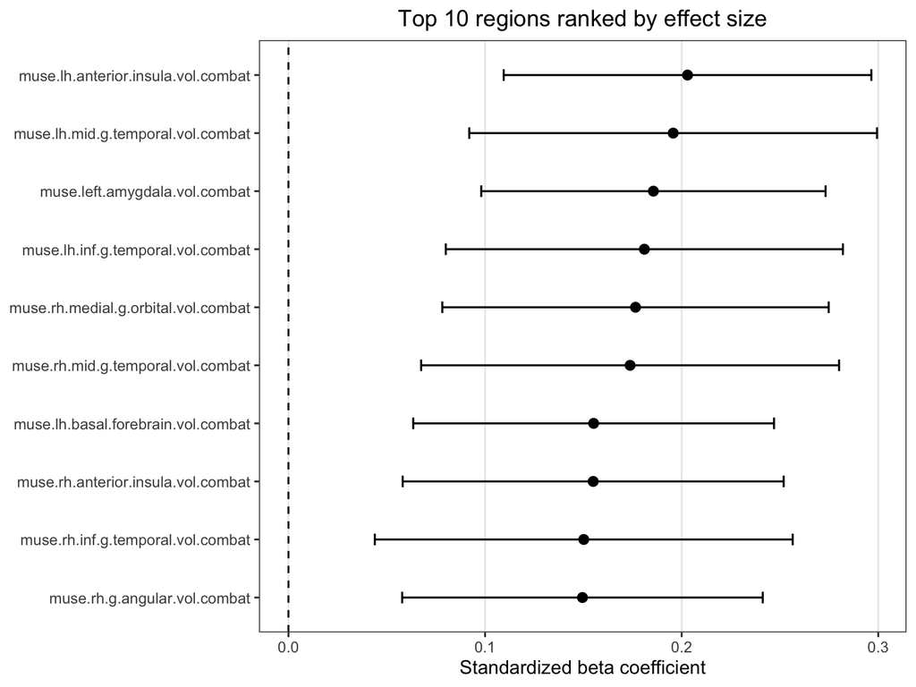

```r
boot_rank <- readRDS("region_gm_bootstrap.rds")

plot_top_region_forest <- function(boot_rank,
                                   top_n = 10,
                                   file = "top_region_forest.pdf",
                                   title = NULL,
                                   xlab = "Standardized beta coefficient",
                                   width = 8,
                                   height = 6) {
  plot_df <- boot_rank$original %>%
    arrange(rank) %>%
    slice_head(n = top_n) %>%
    mutate(
      beta_LCI = beta_std - 1.96 * se,
      beta_UCI = beta_std + 1.96 * se,
      predictor = factor(predictor, levels = rev(predictor)),
      p_label = ifelse(pval < 0.001, "p < 0.001", paste0("p = ", signif(pval, 2)))
    )

  if (is.null(title)) {
    title <- paste0("Top ", top_n, " regions ranked by effect size")
  }

  p <- ggplot(plot_df, aes(x = beta_std, y = predictor)) +
    geom_vline(xintercept = 0, linetype = "dashed") +
    geom_errorbarh(aes(xmin = beta_LCI, xmax = beta_UCI),
                   height = 0.2,
                   linewidth = 0.6) +
    geom_point(size = 2.5) +
    labs(title = title, x = xlab, y = NULL) +
    theme_bw(base_size = 12) +
    theme(
      plot.title = element_text(hjust = 0.5),
      panel.grid.major.y = element_blank(),
      panel.grid.minor = element_blank()
    )

  ggsave(
    filename = file,
    plot = p,
    device = "pdf",
    width = width,
    height = height
  )

  return(p)
}

plot_top_region_forest(boot_rank = boot_rank, top_n = 10, file = "top10_region_forest.pdf")
```

### 3.2.2 Forest Plots (Confidence Interval of Ranks)

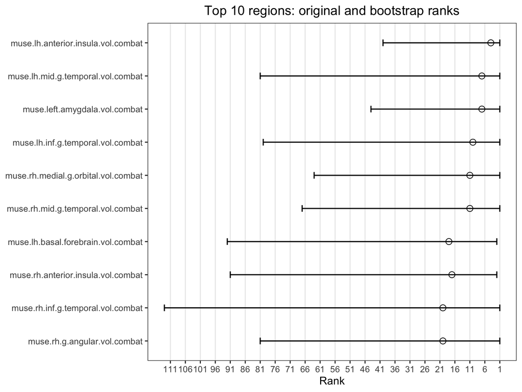

```r
plot_top_region_rank_interval <- function(boot_rank,
                                          top_n = 10,
                                          file = "top_region_rank_interval.pdf",
                                          title = NULL,
                                          xlab = "Rank",
                                          width = 8,
                                          height = 6) {
  plot_df <- boot_rank$rank_summary %>%
    arrange(orig_rank) %>%
    slice_head(n = top_n) %>%
    mutate(
      predictor = factor(predictor, levels = rev(predictor)),
      rank_label = paste0("P(top 5) = ", round(prob_top_5, 2))
    )

  if (is.null(title)) {
    title <- paste0("Top ", top_n, " regions: original and bootstrap ranks")
  }

  p <- ggplot(plot_df, aes(y = predictor)) +
    geom_errorbarh(aes(xmin = rank_LCI, xmax = rank_UCI),
                   height = 0.2,
                   linewidth = 0.6) +
    geom_point(aes(x = rank_median), shape = 1, size = 2.8) +
    scale_x_reverse(breaks = seq(1, max(plot_df$rank_UCI, na.rm = TRUE), by = 5)) +
    labs(title = title, x = xlab, y = NULL) +
    theme_bw(base_size = 12) +
    theme(
      plot.title = element_text(hjust = 0.5),
      panel.grid.major.y = element_blank(),
      panel.grid.minor = element_blank()
    )

  ggsave(
    filename = file,
    plot = p,
    device = "pdf",
    width = width,
    height = height
  )

  return(p)
}

plot_top_region_rank_interval(boot_rank = boot_rank,
                              top_n = 10,
                              file = "top10_region_rank_interval.pdf")
```

### 3.2.3 Forest Plots (X-axis and Labels Update)

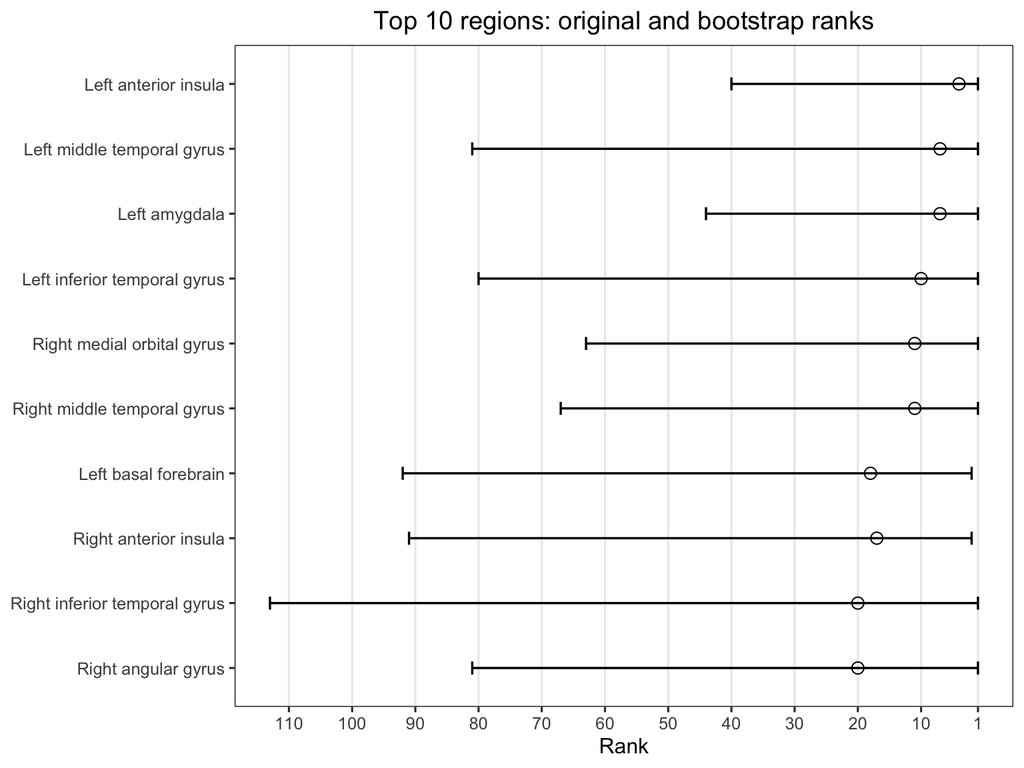

```r
region_labels <- c(
  "muse.rh.g.angular.vol.combat" =
    "Right angular gyrus",

  "muse.rh.inf.g.temporal.vol.combat" =
    "Right inferior temporal gyrus",

  "muse.rh.anterior.insula.vol.combat" =
    "Right anterior insula",

  "muse.lh.basal.forebrain.vol.combat" =
    "Left basal forebrain",

  "muse.rh.mid.g.temporal.vol.combat" =
    "Right middle temporal gyrus",

  "muse.rh.medial.g.orbital.vol.combat" =
    "Right medial orbital gyrus",

  "muse.lh.inf.g.temporal.vol.combat" =
    "Left inferior temporal gyrus",

  "muse.left.amygdala.vol.combat" =
    "Left amygdala",

  "muse.lh.mid.g.temporal.vol.combat" =
    "Left middle temporal gyrus",

  "muse.lh.anterior.insula.vol.combat" =
    "Left anterior insula"
)

plot_top_region_rank_interval <- function(boot_rank,
                                          top_n = 10,
                                          file_pdf = "top_region_rank_interval.pdf",
                                          file_tiff = "top_region_rank_interval.tiff",
                                          title = NULL,
                                          xlab = "Rank",
                                          width = 8,
                                          height = 6,
                                          dpi = 500,
                                          label_map = NULL) {
  plot_df <- boot_rank$rank_summary %>%
    arrange(orig_rank) %>%
    slice_head(n = top_n)

  # Optional: replace variable names with cleaner labels
  if (!is.null(label_map)) {
    plot_df <- plot_df %>%
      mutate(predictor_label = dplyr::recode(predictor, !!!label_map))
  } else {
    plot_df <- plot_df %>%
      mutate(predictor_label = predictor)
  }

  plot_df <- plot_df %>%
    mutate(
      predictor_label = factor(predictor_label, levels = rev(predictor_label)),
      rank_label = paste0("P(top 5) = ", round(prob_top_5, 2))
    )

  if (is.null(title)) {
    title <- paste0("Top ", top_n, " regions: original and bootstrap ranks")
  }

  x_max <- max(plot_df$rank_UCI, na.rm = TRUE)

  p <- ggplot(plot_df, aes(y = predictor_label)) +
    geom_errorbarh(aes(xmin = rank_LCI, xmax = rank_UCI),
                   height = 0.2,
                   linewidth = 0.6) +
    geom_point(aes(x = rank_median), shape = 1, size = 2.8) +
    scale_x_reverse(breaks = c(1, seq(10, x_max, by = 10))) +
    labs(title = title, x = xlab, y = NULL) +
    theme_bw(base_size = 12) +
    theme(
      plot.title = element_text(hjust = 0.5),
      panel.grid.major.y = element_blank(),
      panel.grid.minor = element_blank()
    )

  ggsave(
    filename = file_pdf,
    plot = p,
    device = "pdf",
    width = width,
    height = height
  )

  ggsave(
    filename = file_tiff,
    plot = p,
    device = "tiff",
    width = width,
    height = height,
    dpi = dpi,
    compression = "lzw"
  )

  return(p)
}

plot_top_region_rank_interval(
  boot_rank = boot_rank,
  top_n = 10,
  file_pdf = "top10_region_rank_interval_labeled.pdf",
  file_tiff = "top10_region_rank_interval_labeled.tiff",
  label_map = region_labels
)
```

Extracting individual data points from Figure 3A (Scatterplot) and computing Cohen’s f for the interaction effect.

# 4 McGrath et al. Secondary Analysis Results

```r
set.seed(666)
library(metaDigitise)
library(RESI)
```

```r
#data <- metaDigitise(dir = "./figure")
data = getExtracted(dir = "./figure", summary = FALSE)$scatterplot$figure3a.png
data$x = round(data$x)
data$treatment = as.factor(ifelse(data$x %in% c(1,2), 'CBT', 'Escitalopram'))
data$outcome = as.factor(ifelse(data$x %in% c(1,4), 'NR', 'Remitter'))

mod = lm(y ~ treatment * outcome, data=data)
# effect size values
esRes = anova(resi(mod, vcovfunc = vcov))[3,]
# convert to Cohen's d and t statistic
esRes$d = esRes$RESI * 2
esRes$t = sqrt(esRes$F)
esRes$n = 38

knitr::kable(esRes, caption = "Effect size for Treatment by outcome interaction prediction Insula PET values from Figure 3A of McGrath.")
```

Effect size for Treatment by outcome interaction prediction Insula PET values from Figure 3A of McGrath.

|  | Df | F | Pr(>F) | RESI | 2.5% | 97.5% | d | t | n |
| --- | --- | --- | --- | --- | --- | --- | --- | --- | --- |
| treatment:outcome | 1 | 29.20369 | 8.3e-06 | 0.8908567 | 0.5432726 | 1.338126 | 1.781713 | 5.404044 | 38 |

```r
logModel = glm(outcome ~ treatment * y, data=data, family=binomial)
logModelRed = glm(outcome ~ treatment + y, data=data, family=binomial)
# SNV: This should do a LRT test
esLogistic = anova(logModelRed, logModel, test='LRT')
esLogistic$RESI = NA
esLogistic$RESI[2] = chisq2S(esLogistic$Deviance[2], df=1, n=33)
#resi_pe(logModel, logModelRed, Anova.args = list(test.type='Wald'), anova=FALSE, coefficients=FALSE)
knitr::kable(esLogistic, caption = "Effect size for Treatment by outcome interaction prediction Insula PET values from Figure 3A of McGrath.")
```

Effect size for Treatment by outcome interaction prediction Insula PET values from Figure 3A of McGrath.

| Resid. Df | Resid. Dev | Df | Deviance | Pr(>Chi) | RESI |
| --- | --- | --- | --- | --- | --- |
| 30 | 43.98727 | NA | NA | NA | NA |
| 29 | 21.99662 | 1 | 21.99066 | 2.7e-06 | 0.7975466 |

```r
# compute effect size for HAMA group * treatment response interaction From Table 1
hamaCohenf = f2S(qf(0.009, df1=1, df2=35, lower.tail=FALSE), n = 39, df = 1, rdf = 35)
hamaCohenf
```

```
## [1] 0.3991497
```

## 4.1 Figure 3B Analysis

We quantified the the effect size for the continuous marker from Figure 3B. Comparing this continuous analysis is not actually directly comparable to the one reported in the paper because the dichotomization occurred on the HDRS raw measures and the selection across brain regions was performed using the dichotomized HDRS measures.

```r
# CBT
dataCBT = getExtracted(dir = "./figure", summary = FALSE)$scatterplot$figure3b1.png
dataESC = getExtracted(dir = "./figure", summary = FALSE)$scatterplot$figure3b2.png
dataCBT$group = 'CBT'
dataESC$group = 'Escitalopram'

contData = rbind(dataCBT, dataESC)
# want to model x as the outcome (PET data). Using y is  more consistent with their approach because the used the treatment outcome as a covariate.
mod = lm(y ~ x * group, data=contData)
resiCont = resi(mod, vcovfunc = vcov)
anova(resiCont)[3,]
```

|  | Df | F | Pr(>F) | RESI | 2.5% | 97.5% |
| --- | --- | --- | --- | --- | --- | --- |
| x:group | 1 | 14.74377 | 0.0003030413 | 0.4584996 | 0.2256811 | 0.7418607 |

```r
#
modHDRS = lm(x ~ y * group, data=contData)
resiHDRS = resi(modHDRS)
anova(resiHDRS)[3,]
```

|  | Df | F | Pr(>F) | RESI | 2.5% | 97.5% |
| --- | --- | --- | --- | --- | --- | --- |
| y:group | 1 | 8.896618 | 0.004149117 | 0.347212 | 0.1369413 | 0.6146122 |

We performed an analysis for a dichotomization based on percent change in HDRS from baseline that was preregistered on ClinicalTrials.gov. RESI effect size is equal to Cohen’s $f$ in this case, because we used the parametric covariance.

```r
# secondary outcome that was preregistere
contData$percResp = contData$x< -50
logisticPercHDRS = glm( percResp ~ y * group, data=contData, family=binomial())
resilogisticHDRS = resi(logisticPercHDRS, vcovfunc = vcov)
anova(resilogisticHDRS)
```

|  | Df | Chisq | Pr(>Chisq) | RESI | 2.5% | 97.5% |
| --- | --- | --- | --- | --- | --- | --- |
| y | 1 | 0.41525644 | 0.5193135 | 0.0000000 | 0 | 0.3763900 |
| group | 1 | 0.09345882 | 0.7598252 | 0.0000000 | 0 | 0.2858066 |
| y:group | 1 | 3.80487154 | 0.0511037 | 0.2110018 | 0 | 0.5051728 |

## 4.2 Estimate Remission Rate to Align with Follow-Up Paper

This analysis uses the threshold for the PET measure (1.02437) to compute the remission rate reported in the subsequent paper (Kelley 2021) in the McGrath paper.

```r
PETthr = 1.02437
data$hyptreatment = factor(ifelse(data$y>PETthr, 'Escitalopram', 'CBT'))
data$include = ifelse(data$hyptreatment == data$treatment, 'Yes', 'No')
# This is a binomial test
binom.test(rev(table(data[ data$include=='Yes', c('outcome')])))
```

```
##
##  Exact binomial test
##
## data:  rev(table(data[data$include == "Yes", c("outcome")]))
## number of successes = 14, number of trials = 16, p-value = 0.004181
## alternative hypothesis: true probability of success is not equal to 0.5
## 95 percent confidence interval:
##  0.6165238 0.9844864
## sample estimates:
## probability of success
##                  0.875
```

```r
# This is a binomial test of the treatment effect
binom.test(rev(table(data[, c('outcome')])))
```

```
##
##  Exact binomial test
##
## data:  rev(table(data[, c("outcome")]))
## number of successes = 18, number of trials = 33, p-value = 0.7283
## alternative hypothesis: true probability of success is not equal to 0.5
## 95 percent confidence interval:
##  0.3635065 0.7189338
## sample estimates:
## probability of success
##              0.5454545
```

```bash
export PATH="/Users/simon/fsl/bin:$PATH"
./SupplementaryMaterial/cluster_pvalue.sh
```

Abi-Dargham, Anissa, Scott J. Moeller, Fahad Ali, et al. 2023. “Candidate Biomarkers in Psychiatric Disorders: State of the Field.” *World Psychiatry* 22 (2): 236–62. https://doi.org/10.1002/wps.21078.

Barac, Milica, Caroline W. Grant, Russell Toll, et al. 2026. “Towards Causal Inference-Based Antidepressant Selection with Brain and Blood Biomarkers.” *Neuropsychopharmacology* 51 (3): 622–30. https://doi.org/10.1038/s41386-025-02183-3.

Beer, Joanne. 2020. *longCombat: Longitudinal ComBat for Harmonizing Multi-Batch Longitudinal Data*.

Doshi, Jimit, Guray Erus, Yangming Ou, et al. 2016. “MUSE: MUlti-Atlas Region Segmentation Utilizing Ensembles of Registration Algorithms and Parameters, and Locally Optimal Atlas Selection.” *NeuroImage* 127: 186–95. https://doi.org/10.1016/j.neuroimage.2015.11.073.

Fischer, Adina S., Bailey Holt-Gosselin, Scott L. Fleming, et al. 2021. “Intrinsic Reward Circuit Connectivity Profiles Underlying Symptom and Quality of Life Outcomes Following Antidepressant Medication: A Report from the iSPOT-d Trial.” *Neuropsychopharmacology* 46 (4): 809–19. https://doi.org/10.1038/s41386-020-00905-3.

Liu, Rui, Ximan Hou, Shuyu Liu, et al. 2025. “Predicting Antidepressant Response via Local-Global Graph Neural Network and Neuroimaging Biomarkers.” *Npj Digital Medicine* 8 (1): 515. https://doi.org/10.1038/s41746-025-01912-8.

McGrath, Callie L., Mary E. Kelley, Paul E. Holtzheimer, et al. 2013. “Toward a Neuroimaging Treatment Selection Biomarker for Major Depressive Disorder.” *JAMA Psychiatry* 70 (8): 821–29. https://doi.org/10.1001/jamapsychiatry.2013.143.

Nguyen, Khoa P., Cherise Chin Fatt, Andrew Treacher, et al. 2022. “Patterns of Pretreatment Reward Task Brain Activation Predict Individual Antidepressant Response: Key Results from the EMBARC Randomized Clinical Trial.” *Biological Psychiatry* 91 (6): 550–60. https://doi.org/10.1016/j.biopsych.2021.09.011.

Tozzi, Leonardo, Andrea N. Goldstein-Piekarski, Mayuresh S. Korgaonkar, and Leanne M. Williams. 2020. “Connectivity of the Cognitive Control Network During Response Inhibition as a Predictive and Response Biomarker in Major Depression: Evidence from a Randomized Clinical Trial.” *Biological Psychiatry* 87 (5): 462–72. https://doi.org/10.1016/j.biopsych.2019.08.005.